# Universidad de Costa Rica Estadística Espacial

Tarea 4

Fabián Hernández

Lo primero que hacemos es leer el área(en forma de polígono) con la información de área que queremos analizar.

```r
chi.poly <- readShapePoly('foreclosures.shp')
chi.ols<-lm(violent~est_fcs_rt+bls_unemp, data=chi.poly@data)
class(chi.poly)
```

```
  [1] "SpatialPolygonsDataFrame"
  attr(,"package")
  [1] "sp"
```

Se realiza una regresión lineal simple sin tomar en cuenta la relación espacial de los datos.

```r
chi.ols<-lm(violent~est_fcs_rt+bls_unemp, data=chi.poly@data)
summary(chi.ols)
```

```
  Call:
  lm(formula = violent ~ est_fcs_rt + bls_unemp, data = chi.poly@data)

  Residuals:
      Min      1Q  Median      3Q     Max
  -892.02  -77.02  -23.73   41.90 1238.22

  Coefficients:
              Estimate Std. Error t value Pr(>|t|)
  (Intercept)  -18.627     45.366  -0.411    0.681
  est_fcs_rt    28.298      1.435  19.720   <2e-16 ***
  bls_unemp     -0.308      5.770  -0.053    0.957
  ---
  Signif. codes:  0 '***' 0.001 '**' 0.01 '*' 0.05 '.' 0.1 ' ' 1

  Residual standard error: 157.3 on 894 degrees of freedom
  Multiple R-squared:  0.3141,  Adjusted R-squared:  0.3126
  F-statistic: 204.7 on 2 and 894 DF,  p-value: < 2.2e-16
```

Para empezar a comprobar la relación espacial de las observaciones, se toma como vecino cualquier observación que comparta un limite entre si. El criterio usado es el llamado Queen. Además, se muestra el gráfico con los vecinos de cada poligono según el criterio utilizado.

```r
list.queen<-poly2nb(chi.poly, queen=TRUE)
W<-nb2listw(list.queen, style="W", zero.policy=TRUE)
W
```

```
  Characteristics of weights list object:
  Neighbour list object:
  Number of regions: 897
  Number of nonzero links: 6140
  Percentage nonzero weights: 0.7631036
  Average number of links: 6.845039

  Weights style: W
  Weights constants summary:
      n     nn  S0       S1       S2
  W 897 804609 897 274.4893 3640.864
```

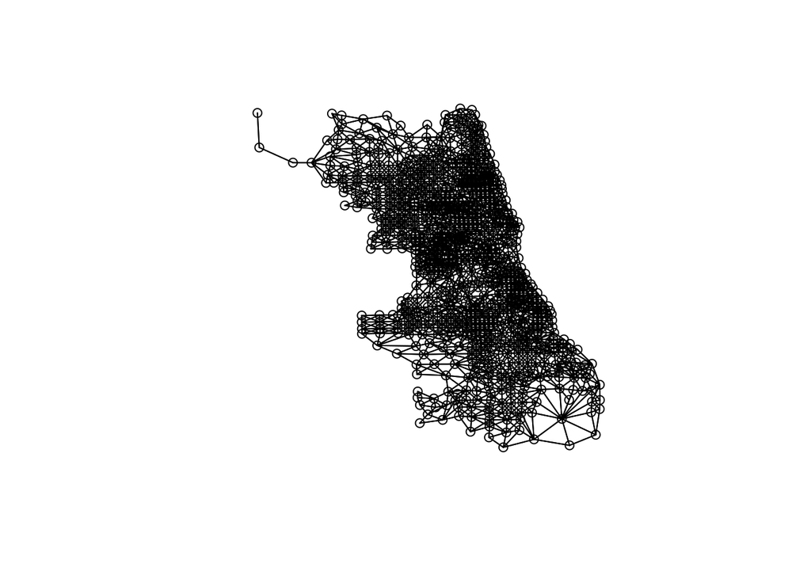

```r
plot(W,coordinates(chi.poly))
```

Si se quisiera por ejemplo, en lugar de usar el criterio de Queen para obtener la matriz de pesos, usar la distancia entre las observaciones, se puede usar la función coordinates, para obtener los centroides de cada uno de los poligonos y la función dnearneigh para escoger los vecinos a x kilometros. En el ejemplo del libro, se estan usando los vecinos a 1km.

```r
coords<-coordinates(chi.poly)
W_dist<-dnearneigh(coords,0,1,longlat = FALSE)
```

Se usa el test de Moran para probar correlación espacial de las observaciones. En este caso se realiza el test con la matriz de pesos con el criterio de Queen. Diferentes escogencias de este criterio de pesos, darían resultados diferentes.

```r
moran.lm<-lm.morantest(chi.ols, W, alternative="two.sided")
print(moran.lm)
```

```
    Global Moran I for regression residuals

  data:
  model: lm(formula = violent ~ est_fcs_rt + bls_unemp, data =
  chi.poly@data)
  weights: W

  Moran I statistic standard deviate = 11.785, p-value < 2.2e-16
  alternative hypothesis: two.sided
  sample estimates:
  Observed Moran I      Expectation         Variance
      0.2142252370    -0.0020099108     0.0003366648
```

Además, se prueba también la correlación espacial, pero esta vez con el test de multiplicadores de Langrange. Este test tiene la ventaja, que si especificado, prueba la presencia de lag espacial y de lag espacial en los errores.

```r
LM<-lm.LMtests(chi.ols, W, test="all")
print(LM)
```

```
    Lagrange multiplier diagnostics for spatial dependence

  data:
  model: lm(formula = violent ~ est_fcs_rt + bls_unemp, data =
  chi.poly@data)
  weights: W

  LMerr = 134.52, df = 1, p-value < 2.2e-16


    Lagrange multiplier diagnostics for spatial dependence

  data:
  model: lm(formula = violent ~ est_fcs_rt + bls_unemp, data =
  chi.poly@data)
  weights: W

  LMlag = 182.18, df = 1, p-value < 2.2e-16


    Lagrange multiplier diagnostics for spatial dependence

  data:
  model: lm(formula = violent ~ est_fcs_rt + bls_unemp, data =
  chi.poly@data)
  weights: W

  RLMerr = 0.00066762, df = 1, p-value = 0.9794


    Lagrange multiplier diagnostics for spatial dependence

  data:
  model: lm(formula = violent ~ est_fcs_rt + bls_unemp, data =
  chi.poly@data)
  weights: W

  RLMlag = 47.653, df = 1, p-value = 5.089e-12


    Lagrange multiplier diagnostics for spatial dependence

  data:
  model: lm(formula = violent ~ est_fcs_rt + bls_unemp, data =
  chi.poly@data)
  weights: W

  SARMA = 182.18, df = 2, p-value < 2.2e-16
```

A la hora de hacer la regresión espacial, se puede hacer de dos maneras. Una es asumiendo normalidad en los errores y por máxima verosimilitud, por medio de la siguiente función. En este caso se hace la regresión espacial, con las variables dependientes del set de datos de violencia en Chicago.

```r
sar.chi<-lagsarlm(violent~est_fcs_rt+bls_unemp, data=chi.poly@data, W)
summary(sar.chi)
```

```
  Call:spatialreg::lagsarlm(formula = formula, data = data, listw = listw,
      na.action = na.action, Durbin = Durbin, type = type, method = method,
      quiet = quiet, zero.policy = zero.policy, interval = interval,
      tol.solve = tol.solve, trs = trs, control = control)

  Residuals:
       Min       1Q   Median       3Q      Max
  -519.127  -65.003  -15.226   36.423 1184.193

  Type: lag
  Coefficients: (asymptotic standard errors)
              Estimate Std. Error z value Pr(>|z|)
  (Intercept) -93.7885    41.3162  -2.270  0.02321
  est_fcs_rt   15.6822     1.5600  10.053  < 2e-16
  bls_unemp     8.8949     5.2447   1.696  0.08989

  Rho: 0.49037, LR test value: 141.33, p-value: < 2.22e-16
  Asymptotic standard error: 0.039524
      z-value: 12.407, p-value: < 2.22e-16
  Wald statistic: 153.93, p-value: < 2.22e-16

  Log likelihood: -5738.047 for lag model
  ML residual variance (sigma squared): 20200, (sigma: 142.13)
  Number of observations: 897
  Number of parameters estimated: 5
  AIC: 11486, (AIC for lm: 11625)
  LM test for residual autocorrelation
  test value: 8.1464, p-value: 0.0043146
```

La otra manera de realizar la regresión espacial es con el método de minimos cuadrados en dos etapas. En la función siguiente se realiza esta regresión.

```r
sar2sls.chi<-stsls(violent~est_fcs_rt+bls_unemp, data=chi.poly@data, W)
summary(sar2sls.chi)
```

```
  Call:spatialreg::stsls(formula = formula, data = data, listw = listw,
      zero.policy = zero.policy, na.action = na.action, robust = robust,
      HC = HC, legacy = legacy, W2X = W2X)

  Residuals:
       Min       1Q   Median       3Q      Max
  -472.703  -61.955  -12.668   36.795 1168.899

  Coefficients:
                 Estimate  Std. Error t value  Pr(>|t|)
  Rho            0.629161    0.082777  7.6007 2.953e-14
  (Intercept) -115.062608   42.648091 -2.6980  0.006977
  est_fcs_rt    12.111383    2.488729  4.8665 1.136e-06
  bls_unemp     11.499706    5.406927  2.1268  0.033433

  Residual variance (sigma squared): 19943, (sigma: 141.22)
```

Se compara los residuos de la regresión ordinal con los residuos de la regresion espacial. Para esto, sobre el mapa original, para ambos escenarios, se hace plot de los residuos. Como era de esperarse, la regresión espacial es más adecuada para este escenario.

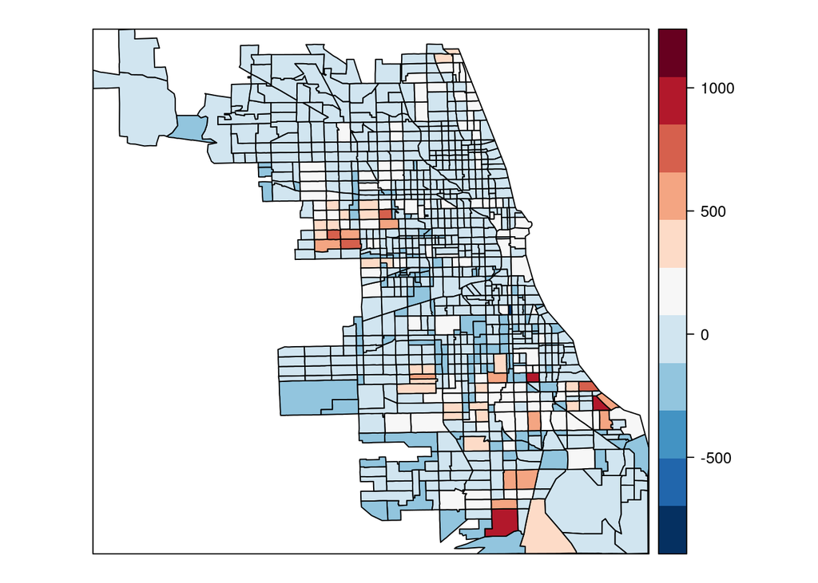

```r
chi.poly@data$chi.ols.res<-resid(chi.ols) #residuals ols

chi.poly@data$chi.sar.res<-resid(sar.chi) #residual sar

spplot(chi.poly,"chi.ols.res", at=seq(min(chi.poly@data$chi.ols.res,na.rm=TRUE),max(chi.poly@data$chi.ols.res,na.rm=TRUE),length=12),col.regions=rev(brewer.pal(11,"RdBu")))
```

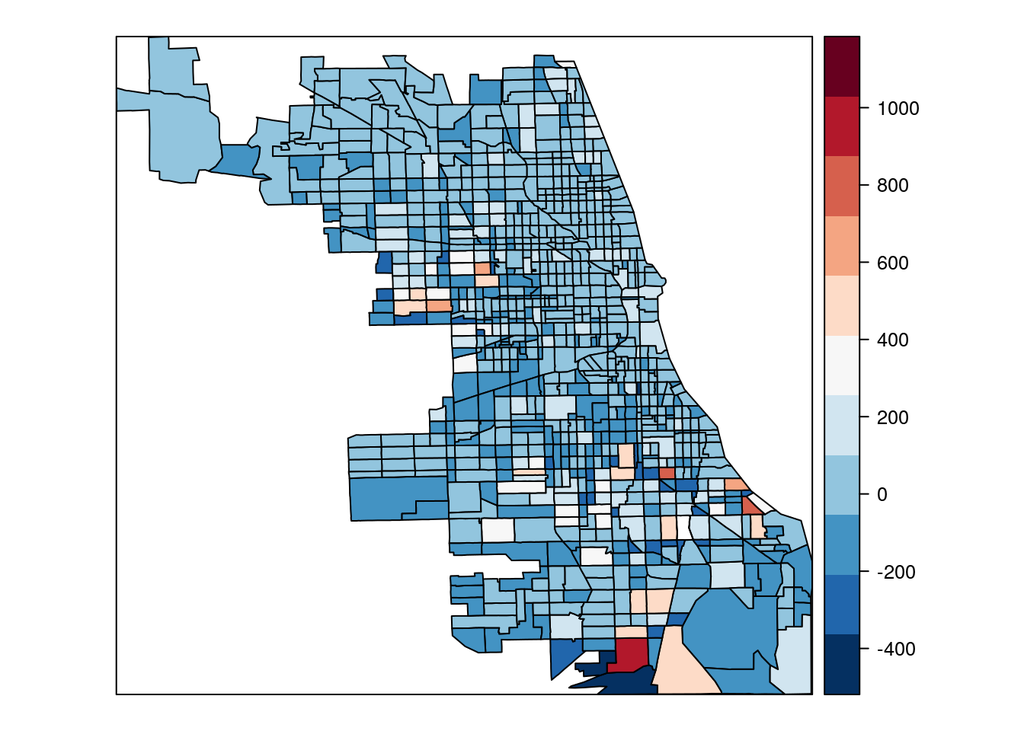

```r
spplot(chi.poly,"chi.sar.res",at=seq(min(chi.poly@data$chi.sar.res,na.rm=TRUE),max(chi.poly@data$chi.sar,na.rm=TRUE), length=12), col.regions=rev(brewer.pal(11,"RdBu")))
```

Con esta función, se puede ver el impacto de las variables utilizadas en la regresión. Siendo la variable est_fcs_rt la de mayor impacto.

```r
impacts(sar.chi, listw=W)
```

```
  Impact measures (lag, exact):
                Direct  Indirect    Total
  est_fcs_rt 16.434478 14.336896 30.77137
  bls_unemp   9.321585  8.131843 17.45343
```

Por último, se estima el modelo de errores espacial primero con estimación de máxima verosimilitud.

```r
errorsalm.chi<-errorsarlm(violent~est_fcs_rt+bls_unemp, data=chi.poly@data, W)
summary(errorsalm.chi)
```

```
  Call:
  spatialreg::errorsarlm(formula = formula, data = data, listw = listw,
      na.action = na.action, Durbin = Durbin, etype = etype, method = method,
      quiet = quiet, zero.policy = zero.policy, interval = interval,
      tol.solve = tol.solve, trs = trs, control = control)

  Residuals:
       Min       1Q   Median       3Q      Max
  -650.506  -64.355  -22.646   35.461 1206.346

  Type: error
  Coefficients: (asymptotic standard errors)
              Estimate Std. Error z value Pr(>|z|)
  (Intercept)  -1.2624    43.0509 -0.0293   0.9766
  est_fcs_rt   19.4620     1.9450 10.0062   <2e-16
  bls_unemp     4.0380     5.5134  0.7324   0.4639

  Lambda: 0.52056, LR test value: 109.68, p-value: < 2.22e-16
  Asymptotic standard error: 0.042291
      z-value: 12.309, p-value: < 2.22e-16
  Wald statistic: 151.51, p-value: < 2.22e-16

  Log likelihood: -5753.875 for error model
  ML residual variance (sigma squared): 20796, (sigma: 144.21)
  Number of observations: 897
  Number of parameters estimated: 5
  AIC: 11518, (AIC for lm: 11625)
```

Y finalmente el mismo modelo, pero con el método de estimación generalizada de minimos cuadrados.

```r
fgls.chi<-GMerrorsar(violent~est_fcs_rt+bls_unemp, data=chi.poly@data, W)
summary(fgls.chi)
```

```
  Call:
  spatialreg::GMerrorsar(formula = formula, data = data, listw = listw,
      na.action = na.action, zero.policy = zero.policy, method = method,
      arnoldWied = arnoldWied, control = control, pars = pars,
      scaleU = scaleU, verbose = verbose, legacy = legacy, se.lambda = se.lambda,
      returnHcov = returnHcov, pWOrder = pWOrder, tol.Hcov = tol.Hcov)

  Residuals:
       Min       1Q   Median       3Q      Max
  -697.623  -76.205  -33.292   44.053 1271.737

  Type: GM SAR estimator
  Coefficients: (GM standard errors)
              Estimate Std. Error z value Pr(>|z|)
  (Intercept)  -1.8587    43.5671 -0.0427   0.9660
  est_fcs_rt   21.1757     1.8752 11.2925   <2e-16
  bls_unemp     2.9037     5.5869  0.5197   0.6032

  Lambda: 0.44789 (standard error): 0.11067 (z-value): 4.0473
  Residual variance (sigma squared): 21515, (sigma: 146.68)
  GM argmin sigma squared: 21607
  Number of observations: 897
  Number of parameters estimated: 5
```